# Tutorial of InstaPrism

Mengying Hu

2024-01-22

## Introduction

**InstaPrism** is R package to deconvolute cellular proportion and gene expression in bulk RNA-Seq data. Based on the same conceptual framework and corresponding generative mode from BayesPrism, **InstaPrism** re-implements BayesPrism in a derandomized framework by replacing the time-consuming Gibbs sampling steps in BayesPrism with a fixed-point algorithm, which greatly accelerated the calculation speed while maintaining highly comparable performance.

This tutorial is associated the latest version of InstaPrism (InstaPrism v0.1.5), which contains the following key modifications:

- introduces a 2-dimensional scaler matrix that can be used to reconstruct any cell.type specific expression of interest, as a memory-efficient alternative to the original 3-d Z array
- enables cell-type-specific expression deconvolution with the updated reference
- adds **build-in reference** tailored for a wide range of cancer types
- introduces `get_Z_array()` function to retrieve 3-d cell type specific expression array (sample $\times$ genes $\times$ cell.type)
- introduces `get_loglikelihood_trace()` function to visualize model’s log likelihood over iterations
- introduces `get_subcluster()` function to identify subcluster structures within each cell type, can be used to specify cell-state information
- `InstaPrism()` function associated with previous tutorial (InstaPrism v0.1.3) can be accessed using the `InstaPrism_legacy()` function

In this tutorial, we provide three examples of running **InstaPrism** and compare the results with BayesPrism.

## Getting started

Load the **InstaPrism** package.

**InstaPrism** works as an independent R package and does not require the users to have BayesPrism installed.  
We recommend the readers to read through the [tutorial](https://github.com/Danko-Lab/BayesPrism/blob/main/tutorial_deconvolution.pdf) of BayePrism before running our examples.  
`extdata` folder associated with this tutorial can be downloaded from [zenodo](https://zenodo.org/record/7730658) repository.

```r
library(InstaPrism)
```

## Example 1: deconvolution on a small simulated dataset

#### Step 1. Create simulated single cell and bulk expression data

The following lines simulate bulk and single-cell expression, as well as marker genes and true proportions that can be used as an example of deconvolution using the simulation model the **BisqueRNA** package.

```r
library(Biobase)
library(BisqueRNA)
cell.types <- c("Neurons", "Astrocytes", "Oligodendrocytes", "Microglia", "Endothelial Cells","others")
avg.props <- c(.5, .2, .15, .07, .03,.05)
sim.data <- SimulateData(n.ind=20, n.genes=1000, n.cells=500, cell.types=cell.types, avg.props=avg.props)
```

sim.data contains the following simulated objects:

- A 1000 $\times$ 10000 single-cell expression object for 20 individuals, with cells annotated with inidivual ID and cell type labels.
- A 1000 $\times$ 20 bulk expression object for 20 individuals.
- A 6 $\times$ 20 matrix indicating cellular proportions for 20 individuals.
- A dataframe indicating marker genes for each cell type

Alternatively, readers can load the example simulated data directly from the **InstaPrism** package.

```r
data("sim.data")
```

#### Step 2. Prepare input for InstaPrism and BayesPrism

Both **InstaPrism** and BayesPrism take single cell profiles as prior information and return deconvolution results for a given bulk expression matrix. To prepare input for InstaPrism and BayesPrism, we need:

- **scExpr**: a single-cell expression data as prior information (raw count or library size normalized expression, without log transformation and scaling)
- **bulk_Expr**: a bulk expression to run deconvolution (raw count or library size normalized expression, without log transformation and scaling)
- **cell.type.labels**: a character vector indicating cell types of each cell from the scRNA data
- **cell.state.labels**: a character vector indicating cell states of each cell from the scRNA data

In real practice, cell.state.labels usually denote different cell states from a same given cell type. For example, malignant cells can be subclustered by different patients to denote different malignant states. With the *sim.data* we created above, we will generate some artificial cell state labels for *Neurons* given individual IDs.

```r
library(Biobase)
sc.eset <- sim.data$sc.eset
bulk.eset <- sim.data$bulk.eset

sc_Expr = exprs(sc.eset)
sc_Expr = apply(sc_Expr,2,function(x)((x/sum(x))*1e+05))

bulk_Expr = exprs(bulk.eset)
bulk_Expr = apply(bulk_Expr,2,function(x)((x/sum(x))*1e+06))

cell_type_labels=sc.eset@phenoData@data[["cellType"]]

# create artifical cell-state labels for Neuron cells: Neuron_A, Neuron_B, Neuron_C
Neurons_states=names(table(sc.eset@phenoData@data$SubjectName))
names(Neurons_states)=c(rep("A",8),rep("B",6),rep("C",6))

cell_state_labels=ifelse(sc.eset@phenoData@data[["cellType"]]=='Neurons',paste0('Neurons_sub',names(Neurons_states)[match(sc.eset@phenoData@data$SubjectName,Neurons_states)]),sc.eset@phenoData@data[["cellType"]])

table(cell_state_labels)
```

```
#> cell_state_labels
#>        Astrocytes Endothelial Cells         Microglia      Neurons_subA
#>              1958               306               727              2014
#>      Neurons_subB      Neurons_subC  Oligodendrocytes            others
#>              1497              1477              1445               576
```

#### Step 3. Run deconvolution with InstaPrism and BayesPrism

`InstaPrism()` is the main deconvolution function. Depending the format of single cell prior information to use, users need to specify the `input_type` argument passed to the function. The `InstaPrism()` function currently support **four** input_types.

Note that in the following examples we will consider a simple implementation where we use prior information from the scRNA Seq directly, without the need to update reference.

**1. InstaPrism with `input_type = 'raw'`**

Under this setting, InstaPrism takes the same input format as BayesPrism:

- **scExpr**: a single-cell expression data as prior information (raw count or CPM normalized expression)
- **bulk_Expr**: a bulk expression to run deconvolution (raw count or TPM normalized expression)
- **cell.type.labels**: a character vector indicating cell types of each cell from the scRNA data
- **cell.state.labels**: a character vector indicating cell states of each cell from the scRNA data

```r
library(tictoc) # load package to measure execution time
tic()
InstaPrism.res = InstaPrism(input_type = 'raw',sc_Expr = sc_Expr,bulk_Expr = bulk_Expr,
                    cell.type.labels = cell_type_labels,cell.state.labels = cell_state_labels)
```

```r
elapsed1 = toc()
```

```
#> 0.161 sec elapsed
```

**2. InstaPrism with `input_type = 'prism'`**

In this mode, users need to first construct a prism object using the BayesPrism package, and then pass the `prismObj` to the `InstaPrism()` function.

```r
library(BayesPrism)
tic()
bp.obj = new.prism(reference = t(sc_Expr),input.type = 'count.matrix',
                   cell.type.labels = cell_type_labels, cell.state.labels = cell_state_labels,
                   mixture = t(bulk_Expr),key = NULL)
InstaPrism.res2 = InstaPrism(input_type = 'prism',prismObj = bp.obj)
```

```r
elapsed2 = toc()
```

```
#> 0.72 sec elapsed
```

**3. InstaPrism with `input_type = 'refPhi'` (recommended)**

Under this setting, users need to pass a pre-defined `refPhi` object containing single cell prior information. To build a `refPhi` object, users can use the `refPrepare()` function with the following arguments:

- **scExpr**: a single-cell expression data as prior information (raw count or CPM normalized expression)
- **cell.type.labels**: a character vector indicating cell types of each cell from the scRNA data
- **cell.state.labels**: a character vector indicating cell states of each cell from the scRNA data

The resulting `refPhi` object contains the following information:

- **phi.cs**: cell state specific reference
- **phi.ct**: cell type specific reference (this information is only required for BayesPrism based reference update)
- **map**: a list with mapping information from cell.states to cell.types

The advantage of using `refPhi` as input is that one doesn’t need to load the large single cell expression matrix every time, and the `refPhi` object can be easily re-implemented once built.

```r
refPhi_obj = refPrepare(sc_Expr, cell_type_labels, cell_state_labels)
tic()
InstaPrism.res3 = InstaPrism(input_type = 'refPhi',bulk_Expr = bulk_Expr,refPhi = refPhi_obj)
```

```r
elapsed3 = toc()
```

```
#> 0.049 sec elapsed
```

**4. InstaPrism with `input_type = 'refPhi_cs'` (recommended)**

Under this setting, users need to specify a pre-defined `refPhi_cs` object which can be built by

```r
refPhi_cs_obj = refPrepare(sc_Expr, cell_type_labels, cell_state_labels,ref_type = 'refPhi_cs')
InstaPrism.res = InstaPrism(input_type = 'refPhi_cs',bulk_Expr = bulk_Expr,refPhi = refPhi_cs_obj)
```

Alternatively, users can use the **built-in reference** provided by InstaPrism, which are all in `refPhi_cs` format.

Using `refPhi_cs` provides a more versatile setting where users can selectively choose which cell-states to include for deconvolution. For example, given the `refPhi` object we built in the previous section, if we only want to include `Neurons_subA` and `Neurons_subB` as cell states of interest, and remove `Neurons_subC` from Neurons, we can:

```r
refPhi_cs_map = refPhi_obj@map
refPhi_cs_map$Neurons = c('Neurons_subA', 'Neurons_subB' )
to_move_id = which(colnames(refPhi_obj@phi.cs) == 'Neurons_subC')
refPhi_cs_obj = new('refPhi_cs',phi.cs = refPhi_obj@phi.cs[,-to_move_id],map = refPhi_cs_map)

InstaPrism.res4 = InstaPrism(input_type = 'refPhi_cs',bulk_Expr = bulk_Expr,refPhi_cs = refPhi_cs_obj)
```

`InstaPrism()` function returns an S4 object containing the following information:

- **Post.ini.cs**: posterior information for cell.states
  - theta: cell.state fraction estimates for each individual
- **Post.ini.ct**: posterior information for cell.types
  - theta: cell.types fraction estimates for each individual
- **map**: a list with mapping information from cell.states to cell.types
- **initial.reference**: an S4 object with scRNA derived reference matrix at cell.type and cell.state levels
- **initial.scaler**: a gene $\times$ sample matrix that can be used to reconstruct cell.state/cell.type specific expression

**Run BayesPrism for comparison**

In the following example, we are setting `update.gibbs = F` for consistency with our previous examples where we only consider single-cell based reference, without updating the reference. Deconvolution with BayesPrism can be called by a single function `run.prism()` as follows:

```r
start.time = Sys.time()
bp.res = run.prism(bp.obj,update.gibbs = F)
end.time=Sys.time()
bp_running_time = difftime(end.time, start.time,units = 'secs') %>% as.numeric()
save(bp.res,bp_running_time,file='extdata/tutorial_example1/bp.res.initial.RData')
```

#### Step 4. Compare deconvolution results: InstaPrism vs BayesPrism

**1. deconvolution performance of InstaPrism**

We provide a useful function `deconv_performance_plot()` that visualize correlations at per-cell.type level. According to the plot, InstaPrism accurately predicts cellular proportions from sim.data

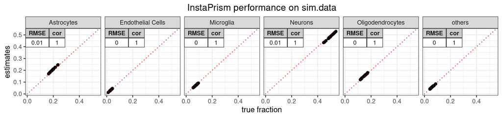

```r
deconv_performance_plot(est = InstaPrism.res@Post.ini.ct@theta,true = sim.data$props,title = 'InstaPrism performance on sim.data',nrow=1)
```

**2. compare cell type fraction estimates from InstaPrism and BayesPrism**

We can visualize the correlation between two fraction estimates with a heatmap. As shown by the heatmap, cell.type estimates from both methods are highly correlated.

```r
corr=cor(t(InstaPrism.res@Post.ini.ct@theta),bp.res@posterior.initial.cellType@theta)
diag(corr)
```

```
#>           Neurons        Astrocytes  Oligodendrocytes         Microglia
#>         0.9999964         0.9999965         0.9999892         0.9999696
#> Endothelial Cells            others
#>         0.9999649         0.9999805
```

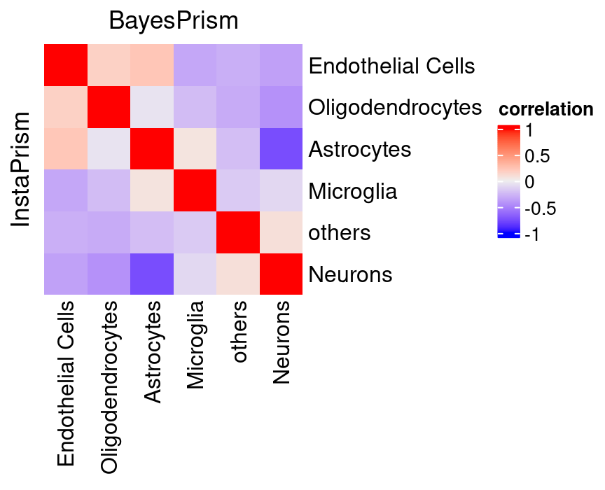

```r
ComplexHeatmap::Heatmap(corr,show_row_dend = F,show_column_dend = F,column_title = 'BayesPrism',row_title = 'InstaPrism',name='correlation')
```

**3. running time comparison** InstaPrism significantly accelerates the deconvolution speed in either modes.

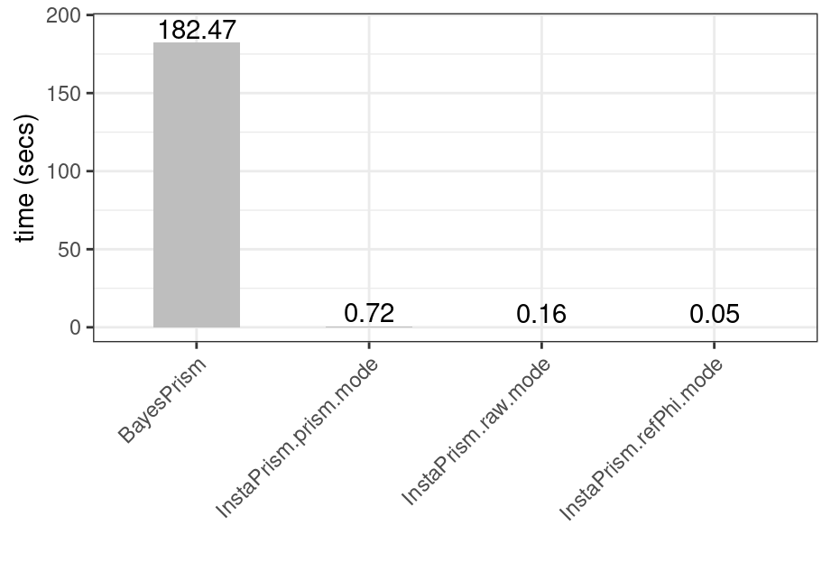

```r
InstaPrism_mode1_running_time = as.numeric(elapsed1$toc-elapsed1$tic)
InstaPrism_mode2_running_time = as.numeric(elapsed2$toc-elapsed2$tic)
InstaPrism_mode3_running_time = as.numeric(elapsed3$toc-elapsed3$tic)

rt=data.frame(method=c('InstaPrism.raw.mode','InstaPrism.prism.mode','InstaPrism.refPhi.mode','BayesPrism'),
              time=c(InstaPrism_mode1_running_time,InstaPrism_mode2_running_time,
                     InstaPrism_mode3_running_time,bp_running_time))
rt$time=round(rt$time,2)
ggplot(rt,aes(method,time))+
  geom_bar(stat="identity",fill='grey',width = 0.5)+
  theme_bw()+
  xlab('')+
  ylab('time (secs)')+
  geom_text(aes(label = time), vjust = -0.2)+
  ylim(0,max(rt$time)*1.05)+
  theme(axis.text.x = element_text(angle = 45, hjust=1))
```

#### Step 5. Reconstruct cell.type specific expression

The 2-dimensional initial.scaler matrix from the InstaPrism output can be used to reconstruct any cell.states/cell.types specific expression of interest, which serves as an extra memory-efficient alternative to the 3-dimensional Z array in the BayesPrism output.

To reconstruct Neurons specific expression from the above example:

```r
Neuron_expr = reconstruct_Z_ct_initial(InstaPrism_obj = InstaPrism.res,
                                       cell.type.of.interest = 'Neurons')
```

And BayesPrism derived Neurons specific expression can be obtained by:

```r
Neuron_expr_bp = t(bp.res@posterior.initial.cellType@Z[,,'Neurons'])
```

Two Neurons specific expression matrices are near identical.

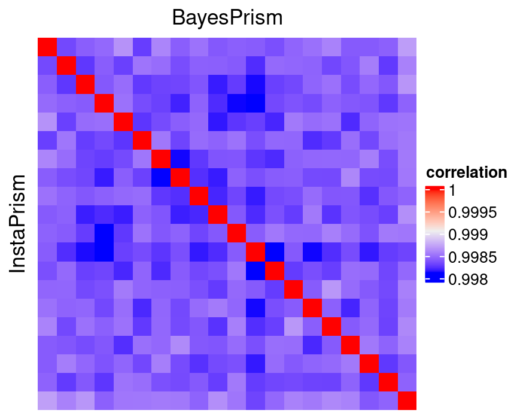

```r
corr = cor(Neuron_expr,Neuron_expr_bp)
ComplexHeatmap::Heatmap(corr,show_row_dend = F,show_column_dend = F,column_title = 'BayesPrism',row_title = 'InstaPrism',name='correlation',cluster_rows = F,cluster_columns = F,show_row_names = F,show_column_names = F)
```

InstaPrism also supports full 3d Z tensor reconstruction (sample $\times$ genes $\times$ cell.type)

```r
Z = get_Z_array(InstaPrism.res,resolution = 'ct',n.core = 16)
```

The dimension of Z is equivalent to BayesPrism output

```r
dim(Z)
```

```
#> [1]  20 988   6
```

```r
dim(bp.res@posterior.initial.cellType@Z)
```

```
#> [1]  20 988   6
```

Two Z tensors are nearly identical

```r
all.equal(Z,bp.res@posterior.initial.cellType@Z)
```

```
#> [1] "Mean relative difference: 0.001901318"
```

#### Step 6 (optional). Run deconvolution with InstaPrism and BayesPrism using the updated reference

We now consider a more advanced deconvolution problem where we want to leverage from the information shared by bulk samples and update the reference matrix accordingly.

In **InstaPrism**, we present a more versatile `InstaPrism_update()` function for a similar purpose, with the following arguments included:

- **cell.types.to.update**: a user-defined vector indicating which (non-malignant) cell.types to update. By default, this parameter is set to ‘all,’ indicating the updating of all cell type references, following the same approach as utilized in BayesPrism.
- **key** name of the malignant cell type. Upon setting the key parameter, the updated malignant reference will be unique for each individual. Set to NA if there is no malignant cells in the problem, and the updated reference will be the same for all the individuals
- **keep.phi**: either ‘phi.ct’ or ‘phi.cs’, denoting whether using phi.ct or phi.cs for cell.types that are not updated.

`InstaPrism_update()` returns an S4 object containing the following objects:

- **theta**: cell state/type abundance matrix
- **psi_mal**: a gene $\times$ sample reference matrix for malignant cells, where each column represents the malignant reference for a corresponding sample; the psi_mal will be a NA matrix if no malignant cells present in the problem
- **psi_env**: reference matrix for the non-malignant cells
- **scaler**: a gene $\times$ sample matrix to reconstruct any cell.type specific expression of interest
- **map**: a list with mapping information from cell.states to cell.types
- **updated.cell.types** a vector indicating cell.types with updated reference; equals to NULL if no environmental (non-malignant) cell.types being updated
- **key**: the `key` argument passed to `InstaPrism_update()` function
- **keep.phi**: the `keep.phi` argument passed to `InstaPrism_update()` function

Among these objects, the ‘theta’ matrix exclusively holds the deconvolution results of interest, while the remaining objects are only required for Z reconstruction.

**1. Reference update using InstaPrism_update()**

To update the reference profile for the above simulated dataset, we will set `key = NA` since no malignant cells are present in this problem. By setting `cell.types.to.update = 'all'`, we specify that all the cell.type reference will be updated.

```r
tic()
InstaPrism.res.updated = InstaPrism_update(InstaPrism.res,
                                           bulk_Expr,
                                           cell.types.to.update = 'all',
                                           key = NA)
```

```
#> the "key" parameter is set to NA, the updated reference will be the same for all the individuals
```

```r
elp = toc()
```

```
#> 0.058 sec elapsed
```

**2. Reference update with BayesPrism**

To enable reference update using BayesPrism, one can set `update.gibbs = TRUE` in `run.prism()` function (the default setting), or by calling the `update.theta()` function on a BayesPrism object returned from `run.prism()` function with `update.gibbs = FALSE`.

For a direct running time comparing between reference update steps, we will first run `run.prism()` function with `update.gibbs = FALSE` and then use the `update.theta()` function.

```r
bp.res = run.prism(bp.obj,update.gibbs = F)

# we will only consider running time for reference updates
start.time = Sys.time()
bp.res.updated = update.theta(bp=bp.res)

# the bp.res.updated obtained by executing run.prism() + update.theta() steps mentioned above is equivalent to running the following command in a single line
# bp.res.updated = run.prism(bp.obj,update.gibbs = T)

end.time=Sys.time()
bp_updated_running_time = difftime(end.time, start.time,units = 'secs') %>% as.numeric()
save(bp.res.updated,bp_updated_running_time,file = 'extdata/tutorial_example1/bp.res.updated.RData')
```

**3. deconvolution results comparison**

When we set `cell.types.to.update` equals to all the unique cell.types present in the reference profile, two deconvolution is near identical.

```r
corr=cor(t(InstaPrism.res.updated@theta),bp.res.updated@posterior.theta_f@theta)
diag(corr)
```

```
#>           Neurons        Astrocytes  Oligodendrocytes         Microglia
#>         0.9999949         0.9999941         0.9999872         0.9999680
#> Endothelial Cells            others
#>         0.9999705         0.9999546
```

**4. running time comparison**

`InstaPrism_update()` demonstrates a substantial acceleration in reference update speed compared to `BayesPrism::update.theta()`

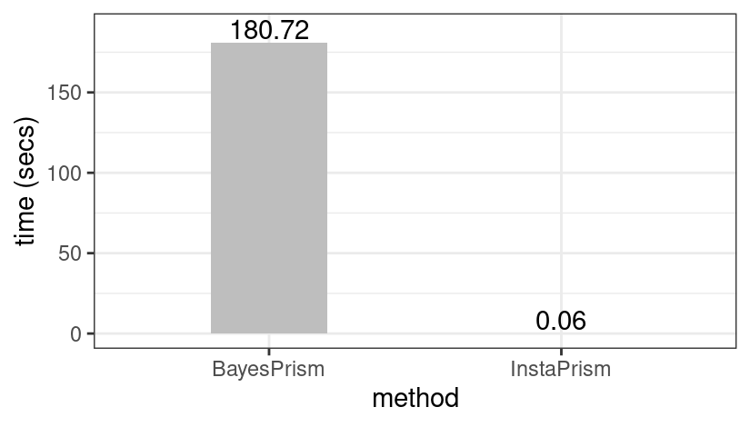

```r
InstaPrism_updated_running_time = as.numeric(elp$toc - elp$tic)
rt=data.frame(method=c('InstaPrism','BayesPrism'),
              time=c(InstaPrism_updated_running_time,bp_updated_running_time))
rt$time=round(rt$time,2)
ggplot(rt,aes(method,time))+
  geom_bar(stat="identity",fill='grey',width = 0.4)+
  theme_bw()+
  ylab('time (secs)')+
  geom_text(aes(label = time), vjust = -0.2)+
  ylim(0,max(rt$time)*1.05)
```

**5. reconstruct cell.type specific expression with the updated reference**

We provide a useful function `reconstruct_Z_ct_updated()` that enables the output of cell-type-specific expression using the updated reference.  
For example, if we are interested in Neurons specific expression with the updated reference, we can

```r
Neuron_expr_updated = reconstruct_Z_ct_updated(InstaPrism_updated_obj = InstaPrism.res.updated,
                                               cell.type.of.interest = 'Neurons')
```

Alternatively, one can use `get_Z_array()` function to get the 3d Z array directly. The dimension of this Z array is sample $\times$ genes $\times$ cell.type.

```r
Z = get_Z_array(InstaPrism.res.updated,resolution = 'ct',n.core = 16)
```

**6. additional notes on InstaPrism_update function**

In the above examples we only considered a simple scenario where we update all the cell.types present. In real practice, we may want to update only specific cell.types, such as those exhibiting high cross-sample heterogeneity, while retaining the scRNA based reference for the remaining cell types. In such cases, users need to specify the `keep.phi` argument, indicating whether to use phi.ct or phi.cs for cell.types that are not updated.

Since either `phi.ct` or `phi.cs` can be used for the cell.types that are not being updated, the `theta` matrix can be a mixture of abundance estimates for both cell.types and cell.states. To merge any cell.state information to cell.type levels, users can utilize the convenient `merge_updated_theta()` function for this purpose. Note that is function is only applicable when `keep.phi = 'phi.cs'`

```r
updated_ct = merge_updated_theta(InstaPrism.res.updated)
```

## Example 2: deconvolution on the tutorial data from BayesPrism

In this example, we will use the tutorial [data](https://github.com/Danko-Lab/BayesPrism/tree/main/tutorial.dat) provided in BayesPrism and compare the deconvolution results between InstaPrism and BayesPrism.

#### Step 1. Run BayesPrism following the [tutorial](https://github.com/Danko-Lab/BayesPrism/blob/main/tutorial_deconvolution.pdf) in BayesPrism.

Note that it takes more than 6 hours to run the following code from our end (using n.core=16), users can skip the BayesPrism running process by loading our processed results directly.

```r
library(BayesPrism)
load('extdata/tutorial_example2/tutorial.gbm.rdata')
sc.stat <- plot.scRNA.outlier(
  input=sc.dat, #make sure the colnames are gene symbol or ENSMEBL ID
  cell.type.labels=cell.type.labels,
  species="hs", #currently only human(hs) and mouse(mm) annotations are supported
  return.raw=TRUE #return the data used for plotting.
  #pdf.prefix="gbm.sc.stat" specify pdf.prefix if need to output to pdf
)
bk.stat <- plot.bulk.outlier(
  bulk.input=bk.dat,#make sure the colnames are gene symbol or ENSMEBL ID
    sc.input=sc.dat, #make sure the colnames are gene symbol or ENSMEBL ID
  cell.type.labels=cell.type.labels,
  species="hs", #currently only human(hs) and mouse(mm) annotations are supported
  return.raw=TRUE
  #pdf.prefix="gbm.bk.stat" specify pdf.prefix if need to output to pdf
)
# Filter outlier genes from scRNA-seq data
sc.dat.filtered <- cleanup.genes (input=sc.dat,
                                  input.type="count.matrix",
                                    species="hs",
                                    gene.group=c( "Rb","Mrp","other_Rb","chrM","MALAT1","chrX","chrY") ,
                                    exp.cells=5)
# Subset protein coding genes
sc.dat.filtered.pc <-  select.gene.type (sc.dat.filtered,
                                        gene.type = "protein_coding")
# construct a prism object
myPrism <- new.prism(
  reference=sc.dat.filtered.pc,
  mixture=bk.dat,
  input.type="count.matrix",
  cell.type.labels = cell.type.labels,
  cell.state.labels = cell.state.labels,
  key="tumor",
  outlier.cut=0.01,
    outlier.fraction=0.1,
)
# run BayesPrism
start.time = Sys.time()
bp.res <- run.prism(prism = myPrism, n.cores=16,update.gibbs=T) # set update.gibbs=T for full comparison between two methods
end.time=Sys.time()
bp_running_time = difftime(end.time, start.time,units = 'mins') %>% as.numeric()
save(bp.res,bp_running_time,file = 'extdata/tutorial_example2/bp.res.RData')
```

Alternatively, users can download the processed results directly from [zenodo](https://zenodo.org/record/7730658) repository

```r
load('extdata/tutorial_example2/bp.res.RData')
```

#### Step 2. Deconvolution with InstaPrism

We present a step-by-step InstaPrism deconvolution framework using the following commands:

```r
tic()
# 1. get initial deconvolution results using scRNA based reference
InstaPrism.res.initial = InstaPrism(input_type = 'prism',prismObj = bp.res@prism, n.iter = 100, n.core = 16)

# 2. reconstruct cell.type specific expression with the initial reference (optional)
Z_ct_initial = get_Z_array(InstaPrism.res.initial,resolution = 'ct',n.core = 16)

# 3. update reference & get deconovlution results from the updated reference
updated_obj = InstaPrism_update(InstaPrism.res.initial,
                                bulk_Expr = t(bp.res@prism@mixture),
                                n.iter = 100,
                                n.core = 16,
                                cell.types.to.update = 'all',
                                key = 'tumor')

# 4. reconstruct cell.type specific expression with the updated reference (optional)
Z_ct_updated = get_Z_array(updated_obj, resolution = 'ct', n.core = 16)
```

```r
elp = toc()
```

```
#> 76.866 sec elapsed
```

#### Step 3. Compare deconvolution results

**1. cell.type fraction comparison (with initial reference)**

cell.type fraction estimates from two methods are nearly identical

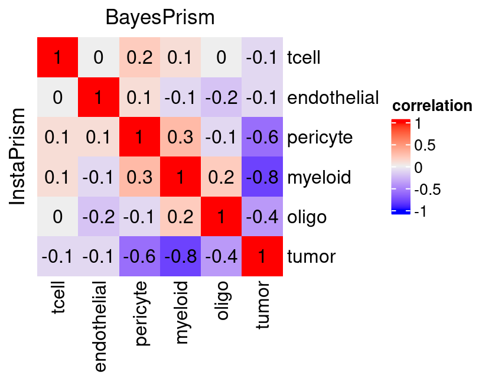

```r
ct.corr=cor(t(InstaPrism.res.initial@Post.ini.ct@theta),bp.res@posterior.initial.cellType@theta) %>% round(1)

ComplexHeatmap::Heatmap(ct.corr,show_row_dend = F,show_column_dend = F,column_title = 'BayesPrism',row_title = 'InstaPrism',name='correlation', cell_fun = function(j, i, x, y, w, h, col) {grid::grid.text(ct.corr[i, j], x, y)})
```

**2. cell type specific expression comparison**

Two tumor-specific expression matrix are near identical

```r
# tumor specific expression from BayesPrism
Z_tumor_ct_initial_bp = bp.res@posterior.initial.cellType@Z[,,'tumor']
all.equal(Z_ct_initial[,,'tumor'],Z_tumor_ct_initial_bp)
```

```
#> [1] "Mean relative difference: 0.005304617"
```

**3. cell.type fraction comparison (with updated reference)**

cell.type fraction estimates from two methods are nearly identical

```r
ct.corr.updated=cor(t(updated_obj@theta),bp.res@posterior.theta_f@theta)
diag(ct.corr.updated)
```

```
#>       tumor     myeloid    pericyte endothelial       tcell       oligo
#>   0.9999576   0.9999839   0.9999233   0.9998641   0.9950594   0.9999056
```

**4. running time comparison** InstaPrism significantly reduced the running time from hours to mere minutes on this tutorial [data](https://github.com/Danko-Lab/BayesPrism/tree/main/tutorial.dat).

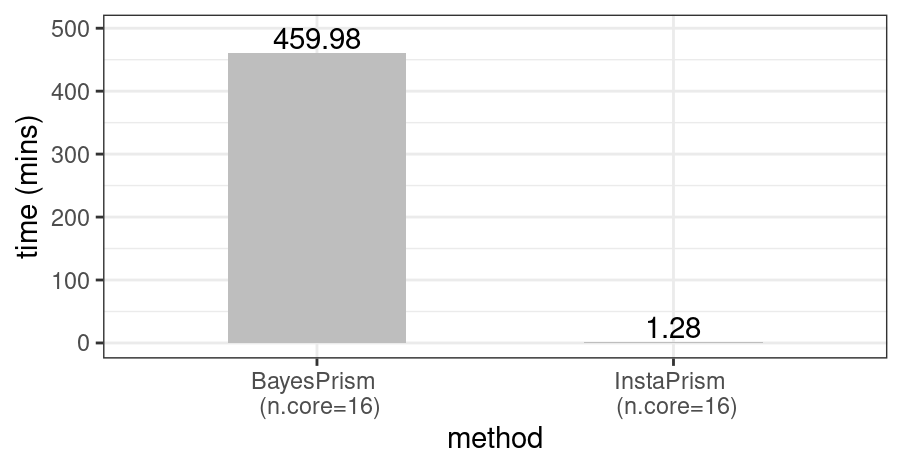

```r
InstaPrism_running_time = as.numeric(elp$toc - elp$tic) / 60 # tic and toc are the elapsed process times in seconds, divide it by 60 to convert to minutes
rt=data.frame(method=c('InstaPrism \n (n.core=16)','BayesPrism \n (n.core=16)'),
              time=c(InstaPrism_running_time,bp_running_time))
rt$time=round(rt$time,2)
ggplot(rt,aes(method,time))+
  geom_bar(stat="identity",fill='grey',width = 0.5)+
  theme_bw()+
  ylab('time (mins)')+
  geom_text(aes(label = time), vjust = -0.2)+
  ylim(0,max(rt$time)*1.08)
```

**5. Memory comparison** With 2-d compression of the Z matrix, InstaPrism significantly reduce the memory required to store the deconvolution object

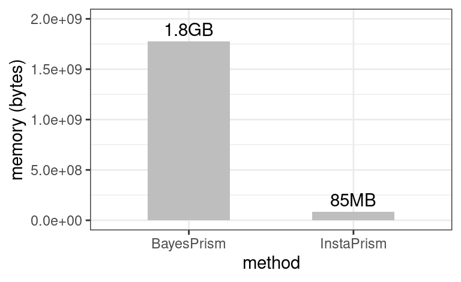

```r
InstaPrism_memory = object.size(c(InstaPrism.res.initial,updated_obj))
bp_memory = object.size(bp.res)

mp=data.frame(method=c('InstaPrism','BayesPrism'),
              memory=c(object.size(c(InstaPrism.res.initial,updated_obj)),object.size(bp.res)),
              m = c('85MB','1.8GB'))

ggplot(mp,aes(method,memory))+
  geom_bar(stat="identity",fill='grey',width = 0.5)+
  theme_bw()+
  ylab('memory (bytes)')+
  geom_text(aes(label = m), vjust = -0.4)+
  ylim(0,2e+09)
```

## Example 3: deconvolution on heterogeneouly simulated bulk data

We have recently proposed a heterogeneous bulk simulation pipeline that simulate bulk samples with realistic biological variance (for more details, check [here](https://github.com/humengying0907/deconvBenchmarking)). In the following example, we will run deconvolution on a heterogeneouly simulated bulk dataset of HNSC tumors and evaluate the deconvolution performance by comparing the fraction estimates with real fractions.

#### Step 1. Load example data

For details about how the bulk samples are simulated, check [here](https://github.com/humengying0907/deconvBenchmarking).

```r
load('extdata/tutorial_example3/example3.RData')
```

The `example3.RData` contains the following objects:

- simulated_bulk: simulated bulk expression of HNSC tumors to run deconvolution
- simulated_frac: simulated cell.type fractions for the bulk samples as ground truth
- scExpr_train: sc-RNA data as prior information
- cell.type.labels: a character vector indicating cell types of each cell from the scRNA data
- cell.state.labels: a character vector indicating cell states of each cell from the scRNA data

where we assign the malignant cells with different cell.states by their patient IDs.

#### Step 2. Run InstaPrism

```r
InstaPrism.res = InstaPrism(input_type = 'raw',sc_Expr = scExpr_train,bulk_Expr = simulated_bulk,
                            cell.type.labels = cell.type.labels, cell.state.labels = cell.state.labels,
                            n.iter = 100,n.core = 16)
```

#### Step 3. Compare InstaPrism results with real cell.type fractions

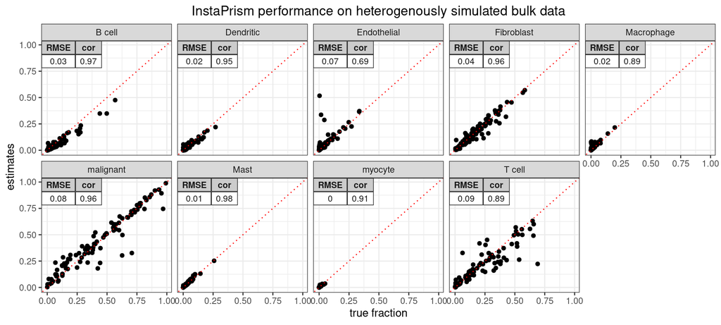

```r
deconv_performance_plot(est = InstaPrism.res@Post.ini.ct@theta,true = t(simulated_frac),title = 'InstaPrism performance on heterogenously simulated bulk data',nrow=2)
```

InstaPrism achieves reasonable cell.type estimates for the simulated bulk samples.

## A complete InstaPrism deconvolution framework

We present the following framework to run deconvolution with InstaPrism

##### 1. get initial deconvolution results using scRNA based reference

Depending on input types, initial deconvolution results can be obtained through:

```r
InstaPrism.res.initial = InstaPrism(input_type = 'raw',sc_Expr,bulk_Expr,cell.type.labels,cell.state.labels,n.core = 16)
InstaPrism.res.initial = InstaPrism(input_type = 'prism',prismObj,n.core = 16)
InstaPrism.res.initial = InstaPrism(input_type = 'refPhi',bulk_Expr, refPhi,n.core = 16)
InstaPrism.res.initial = InstaPrism(input_type = 'refPhi_cs',bulk_Expr, refPhi_cs,n.core = 16)
```

`InstaPrism()` function returns an S4 object containing the following information:

- **Post.ini.cs**: posterior information for cell.states
  - theta: cell.state fraction estimates for each individual
- **Post.ini.ct**: posterior information for cell.types
  - theta: cell.types fraction estimates for each individual
- **map**: a list with mapping information from cell.states to cell.types
- **initial.reference**: an S4 object with scRNA derived reference matrix at cell.type and cell.state levels
- **initial.scaler**: a gene $\times$ sample matrix that can be used to reconstruct cell.state/cell.type specific expression

##### 2. reconstruct cell.state/cell.type specific expression with the initial reference (optional)

```r
Z_cs_initial = reconstruct_Z_cs_initial(InstaPrism.res.initial,cell.state.of.interest)
Z_ct_initial = reconstruct_Z_ct_initial(InstaPrism.res.initial,cell.type.of.interest)
```

`reconstruct_Z_cs_initial()` and `reconstruct_Z_ct_initial()` returns a gene $\times$ sample matrix containing cell-state or cell-type specific expression information.

Alternatively, use `get_Z_array()` to get the 3-d cell.state/cell.type specific expression:

```r
Z_cs_initial = get_Z_array(InstaPrism.res.initial,resolution = 'cs')
Z_ct_initial = get_Z_array(InstaPrism.res.initial,resolution = 'ct')
```

##### 3. update reference & get deconovlution results from the updated reference

```r
updated_obj = InstaPrism_update(InstaPrism.res.initial,
                                bulk_Expr,
                                cell.types.to.update = 'all',
                                key = 'tumor',
                                n.core = 16)
```

`updated_obj@theta` contains cell state/type abundance estimates, while the remaining objects returned by `InstaPrism_update()` is for Z reconstruction only.

##### 4. merge cell.state level theta to cell.type level (optional)

When `updated_obj@theta` contains cell.state abundance estimates, one can use `merge_updated_theta()` function to merge any cell.state information to cell.type levels.

```r
updated_ct = merge_updated_theta(updated_obj)
```

##### 5. reconstruct cell.type specific expression with the updated reference (optional)

```r
Z_ct_updated = get_Z_array(updated_obj,n.core = 16)
```

## Additional notes on InstaPrism parameters

So far we have demonstrated the primary usage of **InstaPrism**, mostly with the default parameters. In real practice, some of the default parameters can be tailored to meet the users’ specific requirements.

- **n.iter**: number of iterations in InstaPrism algorithm.  
  `n.iter` is an important parameter for InstaPrism algorithm. InstaPrism updates the fraction estimates over iterations and `n.iter` determines how many iterations are performed. Under default setting, this value is set to *max(100, number of cell.states $\times$ 2)*. However, users can set it to larger values to improve convergence. Specifically, we included two additional parameters that help to verify the convergence status: *verbose* and *convergence.plot*.
- **verbose**: a logical variable to determine whether to display convergence status of the model.  
  By setting `verbose = T`, `InstaPrsim()` will print the convergence status summary for both cell.states and cell.types.  
  Specifically, the absolute difference in fraction estimates between the last two iterations is utilized as an indicator of convergence (abs_diff), with smaller values indicating convergence and higher confidence of the deconvolution results. Using `example3.RData` as a demonstration, by setting `verbose = T`, we get a summarized table showing the minimum, median and maximum abs_diff for all cell.states/types across the samples. Usually we consider abs_diff < 0.01 as convergence.

```r
load('extdata/tutorial_example3/example3.RData')
InstaPrism.res = InstaPrism(input_type = 'raw',sc_Expr = scExpr_train,bulk_Expr = simulated_bulk,
                            cell.type.labels = cell.type.labels, cell.state.labels = cell.state.labels,
                            n.iter = 100,n.core = 16,verbose = T)
```

```
#> deconvolution with scRNA reference phi
#>
#>
#>  ********************** convergence status summary **********************
#>  instructions:
#>  the absolute difference in fraction estimates between the last two iterations is utilized as an indicator of convergence,
#>  with smaller values indicating convergence (usually consider abs_diff < 0.01 as convergence),
#>  below is a summarized convergence status for cell.states/cell.types across all the samples
#>
#>  *************** convergence status summary for cell states ***************
#>     cell.state          min       median          max
#> 1       B cell 6.572045e-14 2.042905e-06 1.335874e-05
#> 2    Dendritic 1.257843e-07 4.954830e-06 2.266095e-05
#> 3  Endothelial 1.554095e-07 8.878092e-06 4.762081e-05
#> 4   Fibroblast 3.301680e-08 1.627585e-05 6.743852e-05
#> 5        HNSCC 1.278888e-07 2.426794e-05 1.275864e-04
#> 6      HNSCC10 1.091520e-08 1.591293e-06 1.144036e-05
#> 7      HNSCC12 2.139345e-09 5.206182e-07 2.872120e-05
#> 8      HNSCC13 5.232302e-07 2.301956e-05 8.867985e-05
#> 9      HNSCC16 9.318927e-08 2.984146e-05 2.215908e-04
#> 10     HNSCC17 1.417992e-07 2.709896e-05 3.314047e-04
#> 11     HNSCC18 5.775770e-10 3.036487e-07 6.254012e-05
#> 12     HNSCC20 5.802662e-07 1.003421e-05 1.443692e-04
#> 13     HNSCC22 1.080305e-08 2.707936e-05 4.096297e-04
#> 14     HNSCC24 3.619047e-09 1.656969e-06 2.719350e-05
#> 15     HNSCC25 1.389515e-08 2.383273e-05 2.361662e-04
#> 16     HNSCC26 1.013015e-07 2.077936e-05 7.958531e-05
#> 17     HNSCC28 2.987275e-08 3.044526e-05 2.738516e-04
#> 18      HNSCC5 2.497902e-08 6.200813e-06 1.489406e-04
#> 19      HNSCC6 2.433803e-07 1.457819e-05 6.872945e-05
#> 20      HNSCC7 1.243468e-09 3.923414e-06 3.197536e-05
#> 21      HNSCC8 2.316761e-13 3.827862e-07 6.602595e-06
#> 22  Macrophage 1.493925e-07 3.978596e-06 1.398273e-05
#> 23        Mast 5.757529e-11 1.759897e-07 2.972196e-06
#> 24     myocyte 9.239945e-10 2.153556e-07 1.784543e-06
#> 25      T cell 9.902686e-08 1.059614e-05 4.179099e-05
#>
#>  *************** convergence status summary for cell types ***************
#>     cell.type          min       median          max
#> 1      B cell 6.572045e-14 2.042905e-06 1.335874e-05
#> 2   Dendritic 1.257843e-07 4.954830e-06 2.266095e-05
#> 3 Endothelial 1.554095e-07 8.878092e-06 4.762081e-05
#> 4  Fibroblast 3.301680e-08 1.627585e-05 6.743852e-05
#> 5  Macrophage 1.493925e-07 3.978596e-06 1.398273e-05
#> 6   malignant 1.568093e-05 3.891631e-04 9.749845e-04
#> 7        Mast 5.757529e-11 1.759897e-07 2.972196e-06
#> 8     myocyte 9.239945e-10 2.153556e-07 1.784543e-06
#> 9      T cell 9.902686e-08 1.059614e-05 4.179099e-05
#>
#>  ******************* end of convergence status summary ********************
#>
#> scaler calculation
```

- **convergence.plot**: a logical variable determining whether to visualize convergence status for cell types.  
  Again, using `example3.RData` as a demonstration, first let’s consider the scenario when`n.iter` is set too low. According to the convergence plot, fraction estimates for malignant cells did not converge. This means that we should set higher value of `n.iter`.

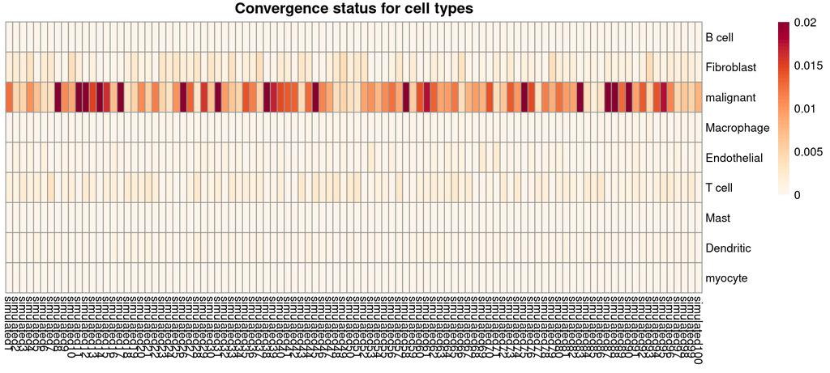

```r
InstaPrism.res = InstaPrism(input_type = 'raw',sc_Expr = scExpr_train,bulk_Expr = simulated_bulk,
                            cell.type.labels = cell.type.labels, cell.state.labels = cell.state.labels,
                            n.iter = 20,n.core = 16,convergence.plot=T,max_n_per_plot = 100)
```

Now, let’s try using a higher value of `n.iter`. This time we get fraction estimation for all the cell types converge (with all the abs_diff less than 0.01).

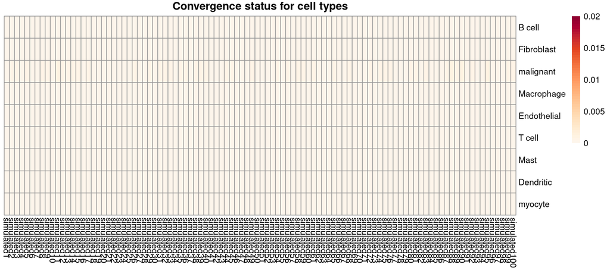

```r
InstaPrism.res = InstaPrism(input_type = 'raw',sc_Expr = scExpr_train,bulk_Expr = simulated_bulk,
                            cell.type.labels = cell.type.labels, cell.state.labels = cell.state.labels,
                            n.iter = 100,n.core = 16,convergence.plot=T,max_n_per_plot = 100)
```

- **n.core**: number of cores to use for parallel programming. We recommend setting this parameter to higher value when multiple cores are available. InstaPrism functions that support parallel programming include: `InstaPrism()`, `InstaPrism_update()`, `reconstruct_Z_ct_initial()`, `reconstruct_Z_ct_updated()` and `InstaPrism_legacy()`.